# Estudios de Informática, Multimedia y Telecomunicaciones

# Minería de datos: PEC1

Autor: Ana Valero Giraldez

Febrero 2025

# 1 Ejercicio 1

A partir de un juego de datos que te parezca interesante, propón un proyecto completo de minería de datos. La organización de la respuesta tiene que coincidir en las fases típicas del ciclo de vida de un proyecto de minería de datos.  
**No hay que realizar las tareas de la fase, este es un ejercicio teórico**.

Se espera por lo tanto que se responda de forma argumentada a las siguientes preguntas (Metodología *CRISP-DM*):

1. **Comprensión del negocio** - ¿Qué necesita el negocio?
2. **Comprensión de los datos** - ¿Qué datos tenemos/necesitamos? ¿Están limpios?
3. **Preparación de los datos** - ¿Cómo organizamos los datos para el modelado?
4. **Modelado** - ¿Qué técnicas de modelado debemos aplicar?
5. **Evaluación** - ¿Qué modelo cumple mejor con los objetivos del negocio?
6. **Implementación** - ¿Cómo acceden los interesados a los resultados?

Para cada fase indica cuál es el objetivo de la fase y el producto que se obtendrá. Utiliza ejemplos de qué y cómo podrían ser las tareas. Si hay alguna característica que hace diferente el ciclo de vida de un proyecto de minería respecto a otros proyectos indícalo.

Extensión mínima: 400 palabras

Para este ejercicio vamos a trabajar con datos de una pulsera smartwatch que ha recogido datos de la actividad diaria de varios usuarios.

## 1.1 Definición de la tarea de minería de datos

**¿Qué necesita el negocio?**

Este proyecto analiza la relación entre la actividad física y el sueño, determinando si el sedentarismo reduce las horas de descanso o si moverse más favorece un mejor dormir. A través del seguimiento de la actividad diaria y las horas de sueño, se establecerá una correlación entre ambos factores. Esto permitirá comprender el impacto del movimiento en la calidad del descanso.

Los datos se han extraído de la web https://www.kaggle.com/datasets/mohammedarfathr/smartwatch-health-data-uncleaned/data Estos datos no están limpios, tendremos que tratarlos antes de extraer conclusiones.

## 1.2 Comprensión de los datos

**¿Qué datos tenemos/necesitamos? ¿Están limpios?**

Se cargan los datos a estudiar en un nuevo dataframe llamado healthData

```r
path = 'unclean_smartwatch_health_data.csv'
healthData <- read.csv(path, row.names=NULL)
```

Realizando el siguiente comando podemos ver qué datos componen el dataset y la cantidad de registros que tenemos.

```r
structure = str(healthData)
```

```
## 'data.frame':    10000 obs. of  7 variables:
##  $ User.ID               : int  4174 NA 1860 2294 2130 2095 4772 4092 3979 3169 ...
##  $ Heart.Rate..BPM.      : num  58.9 NA 247.8 40 62 ...
##  $ Blood.Oxygen.Level....: num  98.8 98.5 97.1 96.9 98.6 ...
##  $ Step.Count            : num  5450 728 2827 13797 15679 ...
##  $ Sleep.Duration..hours.: chr  "7.167235622316564" "6.538239375570314" "ERROR" "7.367789630207228" ...
##  $ Activity.Level        : chr  "Highly Active" "Highly_Active" "Highly Active" "Actve" ...
##  $ Stress.Level          : chr  "1" "5" "5" "3" ...
```

Tenemos **10.000 objetos y 7 variables**.

- **User.ID**: Identificador único que vincula al usuario con sus datos de actividad y salud en el smartwatch.
- **Heart.Rate.BPM.**: Mide los latidos por minuto, variando según la actividad: más alto con ejercicio y más bajo en reposo o sueño.
- **Blood.Oxygen.Level**: Indica el porcentaje de oxígeno en la sangre, siendo normal entre 95% y 100%, clave para la función corporal.
- **Step.Count**: Cuenta los pasos dados por el usuario a lo largo del día, ayudando a monitorear la actividad física diaria.
- **Sleep.Duration..hours.**: Mide las horas totales de sueño del usuario, proporcionando datos sobre la cantidad del descanso.
- **Activity.Level**: Clasifica la actividad diaria en sedentario, activo o altamente activo, según el movimiento y ejercicio realizado.
- **Stress.Level**: Evalúa el estrés a través de la variabilidad del ritmo cardíaco, indicando los niveles de tensión física y emocional.

Vamos a buscar valores nulos o vacíos en las variables.

```r
colSums(is.na(healthData)) #Valores nulos
```

```
##                User.ID       Heart.Rate..BPM. Blood.Oxygen.Level....
##                    201                    400                    300
##             Step.Count Sleep.Duration..hours.         Activity.Level
##                    100                      0                      0
##           Stress.Level
##                      0
```

```r
colSums(healthData=="") #Valores vacíos
```

```
##                User.ID       Heart.Rate..BPM. Blood.Oxygen.Level....
##                     NA                     NA                     NA
##             Step.Count Sleep.Duration..hours.         Activity.Level
##                     NA                    150                      0
##           Stress.Level
##                    200
```

Obsevamos que hay valores nulos en el dataset y valores vacíos. En el analsis de valores nulos podemos ver que tenemos en el **User.ID con 201**, Heart.Rate..BPM. con 400, Blood.Oxygen.Level…. con 300 y **Step.Count con 100**.

Nos interesan los User.ID y Step.Count, aunque el numero de usuarios nulos solo es 2,01% y de pasos 1% lo cual no supondría inconsistencias en los datos ya que no son valores muy elevados.

Estos porcentajes son extraidos de la siguiente manera; Para User.ID = 201 valores nulos/10000 totales * 100 = 2,01% ; Para Step.Count = 100 valores nulos /10000 totales * 100 = 1%

Podemos eliminarlos si queremos con el siguiente comando:

```r
healthDataClear <- na.omit(healthData)
```

En el análisis de valores en blanco, solo hay en los campos **Sleep.Duration..hours. con 150** y Stress.Level con 200, como en el caso anterior el porcentaje es muy pequeño para que suponga una gran inconsistencia.

De todas maneras, como la variable que más nos interesa es las horas de sueño, podemos substituir los valores blancos (y nulos si no los eliminamos), por la mediana.

```r
medianaSleepHours <- median(as.numeric(healthDataClear$Sleep.Duration..hours.), na.rm = TRUE)

print(medianaSleepHours)
```

```
## [1] 6.501197
```

```r
healthDataClear$Sleep.Duration..hours.[healthDataClear$Sleep.Duration..hours. == ""] <- medianaSleepHours #Cambiar los valores en blanco por la mediana

healthDataClear$Sleep.Duration..hours.[is.na(healthDataClear$Sleep.Duration..hours.)] <- medianaSleepHours  #Cambiar los valores nulos por la mediana
```

También podemos observar que hay errores de escritura en las variables Activity.Level. Las analizamos y corregimos.

```r
unique(healthDataClear$Activity.Level) #Todos los valores que toma el campo
```

```
## [1] "Highly Active" "Actve"         "Highly_Active" "Seddentary"
## [5] "Sedentary"     "Active"        "nan"
```

```r
library(dplyr)

healthDataClear <- healthDataClear %>%
  mutate(Activity.Level = recode(Activity.Level,
                         "Actve" = "Active",
                         "Highly Active" = "Highly_Active",
                         "Seddentary" = "Sedentary"))

unique(healthDataClear$Activity.Level) #Valores después de la correción
```

```
## [1] "Highly_Active" "Active"        "Sedentary"     "nan"
```

Podemos verificar también si existen valores duplicados. En la primera comanda nos printa TRUE o FALSE por fila. TRUE = duplicada

En la seguna comanda solo nos muestra las filas duplicadas.

```r
valores_duplicados <- duplicated(healthDataClear)
#print(valores_duplicados) no se muestra por los largos logs

healthDataClear[duplicated(healthDataClear),]
```

```
## [1] User.ID                Heart.Rate..BPM.       Blood.Oxygen.Level....
## [4] Step.Count             Sleep.Duration..hours. Activity.Level
## [7] Stress.Level
## <0 rows> (o 0- extensión row.names)
```

```r
# Eliminar duplicados healthDataClear <- healthDataClear[!duplicated(healthDataClear),]
```

Podemos ver que en este conjunto de datos no existen valores duplicados.

Una vez hemos finalizado este apartado ya tenemos los datos listos limpios para empezar a tratarlos.

## 1.3 Prepración de datos. ¿Como organizamos los datos para el modelado?

**Los campos seleccionados para el minado serán los siguientes: User.ID, Step.Count , Sleep.Duration..hours., Activity.Level**

Este apartado consiste en adecuar los datos que vamos a tratar a los objetivos, utilizando métodos de codificación, discretización, normalización y crossing, también se trabajará la reducción de dimensionalidad con tecnicas como PCA, SVC o outliers.

Para empezar vamos a eliminar las variables que no han sido seleccionadas, que son: Heart.Rate..BPM, Blood.Oxygen.Level y Stress.Level.

**Codificación campo Activity.Level**

Como podemos ver el campo Activity.Level se presenta como un dato categórico y seria interesante convertir este dato a numérico, siendo la correspondencia: Highly_Active = 5; Active = 3; Sedentary = 0.

```r
healthDataClear$Activity.Level.Numeric = with(healthDataClear, ifelse(Activity.Level %in% c("Highly_Active"), 5,ifelse(Activity.Level %in% c("Active"), 3, 0)))
```

**Discretización campo Step.Count**

De la misma manera, tenemos los Step.Count como datos numéricos, pero nos interesaría una medida más correspondiente para poder hacer una estadística clara. Si tiene < 5.000 = Sedentary = 0; Si tiene entre 5.000 y 10.000 = Active = 3; Si tiene > 10000 = Highly Active = 5;

Los criterios de rangos están cogidos de artículos de la OMS.

Realizamos una discretización poniendo los valores de los pasos en rangos, estos rangos se presentarán en valores numéricos simples.

```r
healthDataClear$Step.Count.Transform = with(healthDataClear, ifelse(Step.Count < 5000, 0, ifelse(Step.Count > 5000 & Step.Count < 10000, 3, 5)))

#healthDataClear["Step.Count.Transform"] <- cut(healthDataClear$Step.Count, breaks = c(0,5000,10000,35000), labels = c(0, 3, 5))
```

El campo Sleep.Duration..hours. está guardado como dato caracteres, pero para tratarlos en futuras estadísticas nos interesa que sean datos numéricos.

```r
healthDataClear$Sleep.Duration..hours. <- as.numeric(healthDataClear$Sleep.Duration..hours.)

summary(healthDataClear[c("Step.Count","Sleep.Duration..hours.","Activity.Level.Numeric")])
```

```
##    Step.Count       Sleep.Duration..hours. Activity.Level.Numeric
##  Min.   :    0.91   Min.   :-0.1945        Min.   :0.000
##  1st Qu.: 2004.76   1st Qu.: 5.5059        1st Qu.:0.000
##  Median : 4969.28   Median : 6.5012        Median :3.000
##  Mean   : 6993.16   Mean   : 6.5046        Mean   :2.584
##  3rd Qu.: 9749.44   3rd Qu.: 7.5130        3rd Qu.:5.000
##  Max.   :62486.69   Max.   :12.1402        Max.   :5.000
##                     NA's   :222
```

**Reducción de la dimensionalidad con los outliers**

También vamos a limpiar los datos de los outliers. De esta manera reduciremos la dimensionalidad mediante la reducción de registros que son valores extremos o se desvían de manera significativa. Además, si se aplica un modelado de regresión, como indicamos posteriormente, estos valores límite podrían generar perturbaciones en los resultados.

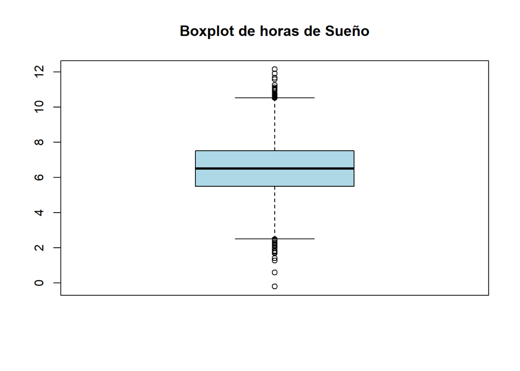

```r
boxplot(healthDataClear$Sleep.Duration..hours., main = "Boxplot de horas de Sueño", col = "lightblue")
```

Podemos ver que obtenemos algunos datos atípicos, estos se representan como puntos. La mayoría de nuestros datos están en la caja representada en azul.

**Crossing para crear Activity.total**

Si vamos a trabajar con un modelo de regresión lineal tendremos en cuenta principalmente las variables de nivel de actividad y horas de sueño. Para crear la variable de Activity.total, sumaremos los datos convertidos a numéricos de Activity.Level y de Step.Count.

```r
healthDataClear$Activity.total <- healthDataClear$Activity.Level.Numeric + healthDataClear$Step.Count.Transform
```

Finalmente, ya tendremos las variables preparadas para aplicar un modelado.

## 1.4 Modelado ¿Que técnicas de modelado debemos aplicar?

Para este conjunto de datos seria interesante utilizar un modelo de regresión para analizar la relación entre la actividad fisica diaria y las horas de sueño.

Por definicion la regresión se utiliza cuando se quiere predecir o entender la relación entre dos o más variables y esto encaja con el modelo de negocio de un smartwatch.

La relación que queremos buscar entre ambas: las personas que duermen más horas son las personas más activas.

Se puede utilizar una regresión lineal simple, buscando unarelacion directa. Si incluimos más datos por ejemplo el estres si que trabajariamos con una regresión lineal múltiple.

```r
#Comando aproximado para obtener una regresión lineal

modelo <- lm(Sleep.Duration..hours. ~ Activity.total, data = healthDataClear)

# Ver el resumen del modelo
summary(modelo)
```

```
##
## Call:
## lm(formula = Sleep.Duration..hours. ~ Activity.total, data = healthDataClear)
##
## Residuals:
##     Min      1Q  Median      3Q     Max
## -6.6978 -0.9977 -0.0037  1.0070  5.6369
##
## Coefficients:
##                 Estimate Std. Error t value Pr(>|t|)
## (Intercept)    6.5009880  0.0293006 221.872   <2e-16 ***
## Activity.total 0.0007804  0.0053871   0.145    0.885
## ---
## Signif. codes:  0 '***' 0.001 '**' 0.01 '*' 0.05 '.' 0.1 ' ' 1
##
## Residual standard error: 1.5 on 8805 degrees of freedom
##   (222 observations deleted due to missingness)
## Multiple R-squared:  2.383e-06,  Adjusted R-squared:  -0.0001112
## F-statistic: 0.02099 on 1 and 8805 DF,  p-value: 0.8848
```

## 1.5 Evaluación ¿Que modelo cumple mejor los objetivos del negocio?

Esta fase consiste en ver si el modelo encaja con los datos obtenidos y lo que esperamos como objetivo. Para la evaluación de los datos, necesitaremos aparte del modelo creado, otro para validarlo y otro para evaluarlo.

Para ello se pueden realizar varias predicciones para ver si los datos que nos proporciona el modelo se clasifica correctamente y que la relación es lineal, el caso de ser exitoso tendremos un modelo de buena calidad.

También verificaremos la proporción de falsos positivos y falsos negativos, en el caso de ser alta tendremos un modelo de baja calidad.

Estas predicciones consistirían en proporcionar horas de actividad diaria, y ver si las horas de sueño predichas cuadran con los datos establecidos y que consideramos correctos. También esto se podría realizar a la inversa, introducir horas de sueño y que nos prediga cuantas horas de actividad diaria se necesitan para cumplir el descanso.

## 1.6 Implementación ¿Como acceden los interesado a los resultados?

Estos resultados pueden ser presentados en el mismo smartwatch o desde la aplicación asociada a este.

# 2 Ejercicio 2

A partir del juego de datos utilizado en el ejemplo de la PEC, realiza las tareas previas a la generación de un modelo de minería de datos explicadas en los módulos “El proceso de minería de datos” y “Preprocesado de los datos y gestión de características”.

Puedes utilizar de referencia el ejemplo de la PEC, pero procura cambiar el enfoque y analizar los datos en función de las diferentes dimensiones que presentan los datos. Así, no se puede utilizar la combinación de variables utilizada en el ejemplo: “FATALS”,“DRUNK_DR”,“VE_TOTAL”,“VE_FORMS”,“PVH_INVL”,“PEDS”,“PERSONS”,“PERMVIT”,“PERNOTMVIT”. Se debe analizar cualquier otra combinación que puede incluir (o no) algunas de estas variables con otras nuevas.

Opcionalmente y valorable se pueden añadir al estudio datos de otros años para realizar comparaciones temporales (https://www.nhtsa.gov/file-downloads?p=nhtsa/downloads/FARS/) o añadir otros hechos a estudiar relacionados, por ejemplo, el consumo de drogas en los accidentes (https://static.nhtsa.gov/nhtsa/downloads/FARS/2020/National/FARS2020NationalCSV.zip)

## 2.1 Descripción del origen del conjunto de datos

Se ha seleccionado un conjunto de datos del [National Highway Traffic Safety Administration](https://www.nhtsa.gov/). El sistema de informes de análisis de mortalidad fue creado en los Estados Unidos por la National Highway Traffic Safety Administration para proporcionar una medida global de la seguridad en las carreteras.

Los datos pertenecen al año 2020. Se trata de un conjunto de registros de accidentes que recogen datos significativos que los describen, conjuntamente con el conjunto de registros de los test de drogas realizados y sus resultados.

El objetivo analítico que tenemos en mente es ver cuantos de estos accidentes mortales están relacionados con la toma de drogas, y en que estado y meses son más propensos.

## 2.2 Análisis exploratorio

El primer paso para realizar un análisis exploratorio es cargar el fichero de datos.

```r
path = 'accident.CSV'
accidentData <- read.csv(path, row.names=NULL)

# Apartado complementario

path = 'drugs.CSV'
drugsData <- read.csv(path, row.names=NULL)
```

### 2.2.1 Exploración del conjunto de datos

```r
structure = str(accidentData)
```

```
## 'data.frame':    35766 obs. of  81 variables:
##  $ STATE       : int  1 1 1 1 1 1 1 1 1 1 ...
##  $ STATENAME   : chr  "Alabama" "Alabama" "Alabama" "Alabama" ...
##  $ ST_CASE     : int  10001 10002 10003 10004 10005 10006 10007 10008 10009 10010 ...
##  $ VE_TOTAL    : int  1 4 2 1 1 2 1 2 2 2 ...
##  $ VE_FORMS    : int  1 4 2 1 1 2 1 2 2 2 ...
##  $ PVH_INVL    : int  0 0 0 0 0 0 0 0 0 0 ...
##  $ PEDS        : int  0 0 0 0 0 0 1 0 0 0 ...
##  $ PERSONS     : int  4 6 2 5 1 3 1 2 4 3 ...
##  $ PERMVIT     : int  4 6 2 5 1 3 1 2 4 3 ...
##  $ PERNOTMVIT  : int  0 0 0 0 0 0 1 0 0 0 ...
##  $ COUNTY      : int  51 73 117 15 37 103 73 25 45 95 ...
##  $ COUNTYNAME  : chr  "ELMORE (51)" "JEFFERSON (73)" "SHELBY (117)" "CALHOUN (15)" ...
##  $ CITY        : int  0 350 0 0 0 0 330 0 0 1500 ...
##  $ CITYNAME    : chr  "NOT APPLICABLE" "BIRMINGHAM" "NOT APPLICABLE" "NOT APPLICABLE" ...
```

[output cut: 67 more lines]

```r
structure = str(drugsData)
```

```
## 'data.frame':    107141 obs. of  9 variables:
##  $ STATE       : int  1 1 1 1 1 1 1 1 1 1 ...
##  $ STATENAME   : chr  "Alabama" "Alabama" "Alabama" "Alabama" ...
##  $ ST_CASE     : int  10001 10001 10001 10001 10002 10002 10002 10002 10002 10002 ...
##  $ VEH_NO      : int  1 1 1 1 1 1 1 1 2 3 ...
##  $ PER_NO      : int  1 2 3 4 1 1 1 2 1 1 ...
##  $ DRUGSPEC    : int  1 0 1 1 1 1 1 0 0 0 ...
##  $ DRUGSPECNAME: chr  "Whole Blood" "Test Not Given" "Whole Blood" "Whole Blood" ...
##  $ DRUGRES     : int  1 0 1 1 151 402 177 0 0 0 ...
##  $ DRUGRESNAME : chr  "Tested, No Drugs Found/Negative" "Test Not Given" "Tested, No Drugs Found/Negative" "Tested, No Drugs Found/Negative" ...
```

Tenemos **35766 registros y 81 variables** en los datos de **accidentes**.

Las variables totales se han comentado en el ejemplo. De este conjunto de datos se utilizaran para el analisis las siguientes variables:

- **ST_CASE** identificador de accidente
- **FATAL** muertes
- **DRUNK_DR** conductores bebidos
- **STATE** codificación de estado
- **STATENAME** nombre de estado
- **MONTH** mes
- **MONTHNAME** nombre de mes

Tenemos **107141 registros y 9 variables** en los datos de **drogas**. Se utilizaran los siguientes datos:

- **ST_CASE** identificador de accidente
- **STATE** codificación de estado
- **STATENAME** nombre de estado
- **VEH_NO** numero del vehiculo
- **PER_NO** numero del persona
- **DRUGSPEC** valor de si se ha realizado un test de drogas . 1 = Si ; 0= No
- **DRUGSPECNAME** descripción del tipo de test de drogas
- **DRUGRES** codificación de la droga tomada.
- **DRUGRESNAME** Nombre de la droga o comentario del test de drogas.

### 2.2.2 Procesamiento de datos y gestión de caracteristicas

#### 2.2.2.1 Limpieza

**Verificación de vacíos o nulos**

Tenemos que limpiar los datos verificando si hay valores vacíos o nulos.

```r
colSums(is.na(accidentData))
```

```
##        STATE    STATENAME      ST_CASE     VE_TOTAL     VE_FORMS     PVH_INVL
##            0            0            0            0            0            0
##         PEDS      PERSONS      PERMVIT   PERNOTMVIT       COUNTY   COUNTYNAME
##            0            0            0            0            0            0
##         CITY     CITYNAME          DAY      DAYNAME        MONTH    MONTHNAME
##            0            0            0            0            0            0
##         YEAR     DAY_WEEK DAY_WEEKNAME         HOUR     HOURNAME       MINUTE
##            0            0            0            0            0            0
##   MINUTENAME          NHS      NHSNAME        ROUTE    ROUTENAME      TWAY_ID
##            0            0            0            0            0            0
##     TWAY_ID2      RUR_URB  RUR_URBNAME     FUNC_SYS FUNC_SYSNAME     RD_OWNER
##            0            0            0            0            0            0
## RD_OWNERNAME       MILEPT   MILEPTNAME     LATITUDE LATITUDENAME     LONGITUD
##            0            0            0            0            0            0
## LONGITUDNAME       SP_JUR   SP_JURNAME      HARM_EV  HARM_EVNAME     MAN_COLL
##            0            0            0            0            0            0
## MAN_COLLNAME      RELJCT1  RELJCT1NAME      RELJCT2  RELJCT2NAME      TYP_INT
##            0            0            0            0            0            0
##  TYP_INTNAME     WRK_ZONE WRK_ZONENAME     REL_ROAD REL_ROADNAME     LGT_COND
##            0            0            0            0            0            0
## LGT_CONDNAME      WEATHER  WEATHERNAME      SCH_BUS  SCH_BUSNAME         RAIL
##            0            0            0            0            0            0
##     RAILNAME     NOT_HOUR NOT_HOURNAME      NOT_MIN  NOT_MINNAME     ARR_HOUR
##            0            0            0            0            0            0
## ARR_HOURNAME      ARR_MIN  ARR_MINNAME      HOSP_HR  HOSP_HRNAME      HOSP_MN
##            0            0            0            0            0            0
##  HOSP_MNNAME       FATALS     DRUNK_DR
##            0            0            0
```

```r
colSums(accidentData=="")
```

```
##        STATE    STATENAME      ST_CASE     VE_TOTAL     VE_FORMS     PVH_INVL
##            0            0            0            0            0            0
##         PEDS      PERSONS      PERMVIT   PERNOTMVIT       COUNTY   COUNTYNAME
##            0            0            0            0            0            0
##         CITY     CITYNAME          DAY      DAYNAME        MONTH    MONTHNAME
##            0            0            0            0            0            0
##         YEAR     DAY_WEEK DAY_WEEKNAME         HOUR     HOURNAME       MINUTE
##            0            0            0            0            0            0
##   MINUTENAME          NHS      NHSNAME        ROUTE    ROUTENAME      TWAY_ID
##            0            0            0            0            0            0
##     TWAY_ID2      RUR_URB  RUR_URBNAME     FUNC_SYS FUNC_SYSNAME     RD_OWNER
##        26997            0            0            0            0            0
## RD_OWNERNAME       MILEPT   MILEPTNAME     LATITUDE LATITUDENAME     LONGITUD
##            0            0            0            0            0            0
## LONGITUDNAME       SP_JUR   SP_JURNAME      HARM_EV  HARM_EVNAME     MAN_COLL
##            0            0            0            0            0            0
## MAN_COLLNAME      RELJCT1  RELJCT1NAME      RELJCT2  RELJCT2NAME      TYP_INT
##            0            0            0            0            0            0
##  TYP_INTNAME     WRK_ZONE WRK_ZONENAME     REL_ROAD REL_ROADNAME     LGT_COND
##            0            0            0            0            0            0
## LGT_CONDNAME      WEATHER  WEATHERNAME      SCH_BUS  SCH_BUSNAME         RAIL
##            0            0            0            0            0            0
##     RAILNAME     NOT_HOUR NOT_HOURNAME      NOT_MIN  NOT_MINNAME     ARR_HOUR
##            0            0            0            0            0            0
## ARR_HOURNAME      ARR_MIN  ARR_MINNAME      HOSP_HR  HOSP_HRNAME      HOSP_MN
##            0            0            0            0            0            0
##  HOSP_MNNAME       FATALS     DRUNK_DR
##            0            0            0
```

Verificamos que no hay valores nulos en los datos ni campos con valores en blanco. Encontrarmos en los datos de accidente el campo TWAY_ID2 con 26997 valores en blanco pero no nos interesa.

```r
colSums(is.na(drugsData))
```

```
##        STATE    STATENAME      ST_CASE       VEH_NO       PER_NO     DRUGSPEC
##            0            0            0            0            0            0
## DRUGSPECNAME      DRUGRES  DRUGRESNAME
##            0            0            0
```

```r
colSums(drugsData=="")
```

```
##        STATE    STATENAME      ST_CASE       VEH_NO       PER_NO     DRUGSPEC
##            0            0            0            0            0            0
## DRUGSPECNAME      DRUGRES  DRUGRESNAME
##            0            0            0
```

Tampoco hay valores nulos o en blanco en los datos de drogas.

En el caso de que hubieramos encontrado datos y que influyeran el campos que vamos a utilizar podemos substituir estos datos por media/mediana/moda en vez de eliminiarlos.

**Verificación de errores tipograficos**

Revisaremos que los datos categoricos que vamos a utilizar no tengan errores de tipográficos

```r
unique(drugsData$STATENAME)
```

```
##  [1] "Alabama"              "Alaska"               "Arizona"
##  [4] "Arkansas"             "California"           "Colorado"
##  [7] "Connecticut"          "Delaware"             "District of Columbia"
## [10] "Florida"              "Georgia"              "Hawaii"
## [13] "Idaho"                "Illinois"             "Indiana"
## [16] "Iowa"                 "Kansas"               "Kentucky"
## [19] "Louisiana"            "Maine"                "Maryland"
## [22] "Massachusetts"        "Michigan"             "Minnesota"
## [25] "Mississippi"          "Missouri"             "Montana"
## [28] "Nebraska"             "Nevada"               "New Hampshire"
## [31] "New Jersey"           "New Mexico"           "New York"
## [34] "North Carolina"       "North Dakota"         "Ohio"
## [37] "Oklahoma"             "Oregon"               "Pennsylvania"
## [40] "Rhode Island"         "South Carolina"       "South Dakota"
## [43] "Tennessee"            "Texas"                "Utah"
## [46] "Vermont"              "Virginia"             "Washington"
## [49] "West Virginia"        "Wisconsin"            "Wyoming"
```

```r
unique(accidentData$STATENAME)
```

```
##  [1] "Alabama"              "Alaska"               "Arizona"
##  [4] "Arkansas"             "California"           "Colorado"
##  [7] "Connecticut"          "Delaware"             "District of Columbia"
## [10] "Florida"              "Georgia"              "Hawaii"
## [13] "Idaho"                "Illinois"             "Indiana"
## [16] "Iowa"                 "Kansas"               "Kentucky"
## [19] "Louisiana"            "Maine"                "Maryland"
## [22] "Massachusetts"        "Michigan"             "Minnesota"
## [25] "Mississippi"          "Missouri"             "Montana"
## [28] "Nebraska"             "Nevada"               "New Hampshire"
## [31] "New Jersey"           "New Mexico"           "New York"
## [34] "North Carolina"       "North Dakota"         "Ohio"
## [37] "Oklahoma"             "Oregon"               "Pennsylvania"
## [40] "Rhode Island"         "South Carolina"       "South Dakota"
## [43] "Tennessee"            "Texas"                "Utah"
## [46] "Vermont"              "Virginia"             "Washington"
## [49] "West Virginia"        "Wisconsin"            "Wyoming"
```

```r
unique(accidentData$MONTHNAME)
```

```
##  [1] "January"   "February"  "March"     "April"     "May"       "June"
##  [7] "July"      "August"    "September" "November"  "October"   "December"
```

**Verificación de valores duplicados**

```r
accidentData_duplicados <- duplicated(accidentData)
drugsData_duplicados <- duplicated(drugsData)
#print(accidentData_duplicados) no se muestra por los largos logs
#print(drugsData_duplicados) no se muestra por los largos logs

accidentData[duplicated(accidentData),]
```

```
##  [1] STATE        STATENAME    ST_CASE      VE_TOTAL     VE_FORMS
##  [6] PVH_INVL     PEDS         PERSONS      PERMVIT      PERNOTMVIT
## [11] COUNTY       COUNTYNAME   CITY         CITYNAME     DAY
## [16] DAYNAME      MONTH        MONTHNAME    YEAR         DAY_WEEK
## [21] DAY_WEEKNAME HOUR         HOURNAME     MINUTE       MINUTENAME
## [26] NHS          NHSNAME      ROUTE        ROUTENAME    TWAY_ID
## [31] TWAY_ID2     RUR_URB      RUR_URBNAME  FUNC_SYS     FUNC_SYSNAME
## [36] RD_OWNER     RD_OWNERNAME MILEPT       MILEPTNAME   LATITUDE
## [41] LATITUDENAME LONGITUD     LONGITUDNAME SP_JUR       SP_JURNAME
## [46] HARM_EV      HARM_EVNAME  MAN_COLL     MAN_COLLNAME RELJCT1
## [51] RELJCT1NAME  RELJCT2      RELJCT2NAME  TYP_INT      TYP_INTNAME
## [56] WRK_ZONE     WRK_ZONENAME REL_ROAD     REL_ROADNAME LGT_COND
## [61] LGT_CONDNAME WEATHER      WEATHERNAME  SCH_BUS      SCH_BUSNAME
## [66] RAIL         RAILNAME     NOT_HOUR     NOT_HOURNAME NOT_MIN
## [71] NOT_MINNAME  ARR_HOUR     ARR_HOURNAME ARR_MIN      ARR_MINNAME
## [76] HOSP_HR      HOSP_HRNAME  HOSP_MN      HOSP_MNNAME  FATALS
## [81] DRUNK_DR
## <0 rows> (o 0- extensión row.names)
```

```r
#drugsData[duplicated(drugsData),] no se muestra por los largos logs
```

```r
# Eliminar duplicados accidentData <- accidentData[!duplicated(accidentData),]
drugsData <- drugsData[!duplicated(drugsData),]
```

### 2.2.3 Datos en contexto

El objetivo de este análisis es ver cuantos de estos accidentes mortales están relacionados con la toma de drogas, y en que estado y meses son más propensos.

Teniendo esto en cuenta y para situarnos en el contexto, vamos a describir los valores en términos generales.Y generar los primeros histogramas.

```r
summary(accidentData[c("FATALS")])
```

```
##      FATALS
##  Min.   :1.000
##  1st Qu.:1.000
##  Median :1.000
##  Mean   :1.085
##  3rd Qu.:1.000
##  Max.   :8.000
```

Realizando un **resumen de la variable FATALS** podemos comprender que en el conjunto de datos se reporta una muerte como minimo, siendo el accidente más grave con 8 victimas. Teniendo esto encuenta, podemos suponer que cada ST_CASE abierto correspondera a un accidente mortal.

Seguidamente, vamos a analizar el número de muertes por estado.

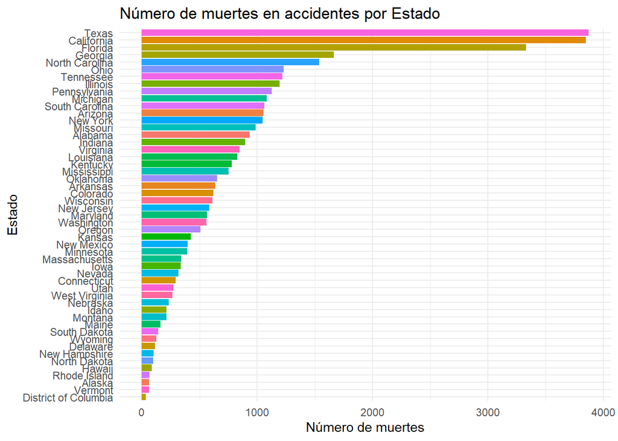

```r
library(ggplot2)
library(dplyr)

objeto <- 1:56

listname <- character(length(objeto))
listfatal <- numeric(length(objeto))
listid <- numeric(length(objeto))

for(i in seq_along(objeto)) {
  elemento <- objeto[i]

  # Recogemos los datos que coinciden con el estado
  matching_rows <- accidentData[accidentData$STATE == elemento, ]

  # Recogemos el nombre del estado
  listname[i] <- unique(matching_rows$STATENAME)[1]

  # Recogemos la suma de muertes por estado
  listfatal[i] <- sum(matching_rows$FATALS, na.rm = TRUE)
  listid[i] <- i

}

# Creamos un dataframe accidentDataStateFatals a partir de los datos añadidos en la lista
accidentDataStateFatals <- data.frame(ID_STATE = listid, STATENAME=listname, FATALS = listfatal)

#Eliminamos los datos nulos
accidentDataStateFatals <- na.omit(accidentDataStateFatals)


#Recogemos los datos del dataframe creado accidentDataStateFatals
ggplot(accidentDataStateFatals, aes(x = reorder(STATENAME, FATALS), y = FATALS, fill = STATENAME)) +
  geom_col() +
  coord_flip() +
  ggtitle("Número de muertes en accidentes por Estado") +
  labs(x = "Estado", y = "Número de muertes") +
  theme_minimal() +
  theme(legend.position = "none")
```

```r
max(accidentDataStateFatals$FATALS)
```

```
## [1] 3874
```

Podemos concluir, que los estados más propensos a tener accidentes mortales son Texas, California y Florida. Siendo así los menos propensos District of Columbia, Vermont y Alaska.

**Texas recoge un total de 3874 muertes**

```r
max(accidentDataStateFatals$FATALS)
```

```
## [1] 3874
```

Vamos a indagar dentro de este estado en que meses se han producido más muertes. Generamos el siguiente histograma:

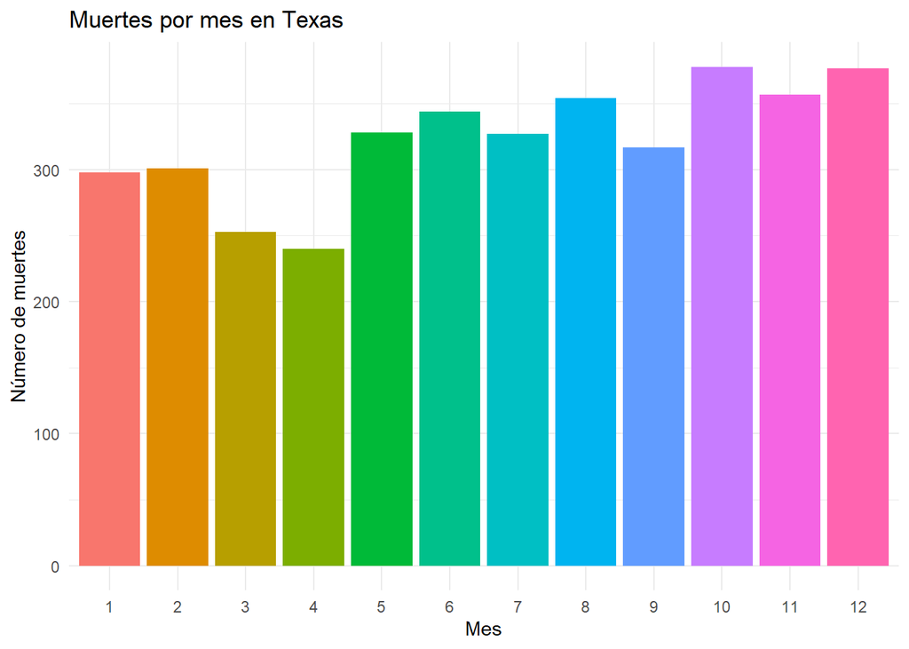

```r
library(ggplot2)
library(dplyr)


estado_seleccionado <- "Texas"  # Cambia esto por el estado que quieras analizar

accidentData_estado <- accidentData %>%
  filter(STATENAME == estado_seleccionado)

ggplot(accidentData_estado, aes(x = factor(MONTH, levels = 1:12), y = FATALS, fill = as.factor(MONTH))) +
  geom_col() +
  ggtitle(paste("Muertes por mes en", estado_seleccionado)) +
  labs(x = "Mes", y = "Número de muertes") +
  theme_minimal() +
  theme(legend.position = "none")
```

Podemos ver que los **meses de octubre y diciembre son los que más presentan accidentes**. Podemos crear la **hipótesis de que estas fechas coinciden con el inicio de las festividades navideñas o con Halloween**, pero no estamos seguros de ello.

Vamos a crear un histograma para refutar o no nuestra hipótesis.

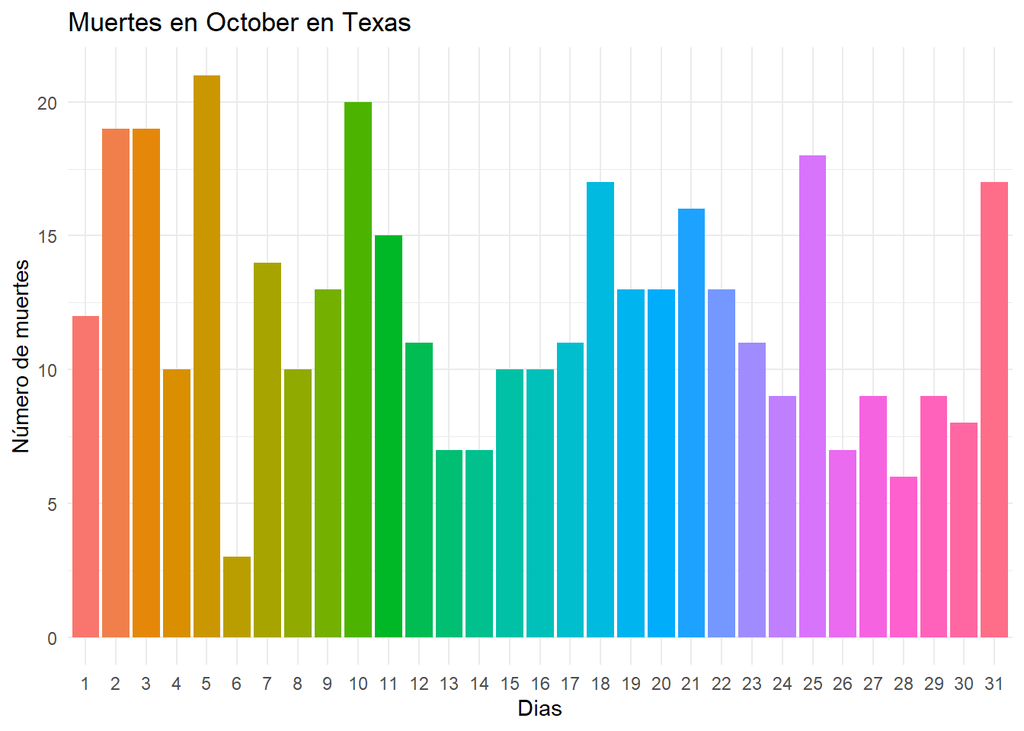

```r
library(ggplot2)
library(dplyr)

estado_seleccionado <- "Texas"  # Cambia esto por el estado que quieras analizar
mes_seleccionado1 <- "October"
mes_seleccionado2 <- "December"

accidentData_estado <- accidentData %>%
  filter(STATENAME == estado_seleccionado & MONTHNAME == mes_seleccionado1)

ggplot(accidentData_estado, aes(x = factor(DAY), y = FATALS, fill = as.factor(DAY))) +
  geom_col() +
  ggtitle(paste("Muertes en", mes_seleccionado1, "en",estado_seleccionado)) +
  labs(x = "Dias", y = "Número de muertes") +
  theme_minimal() +
  theme(legend.position = "none")
```

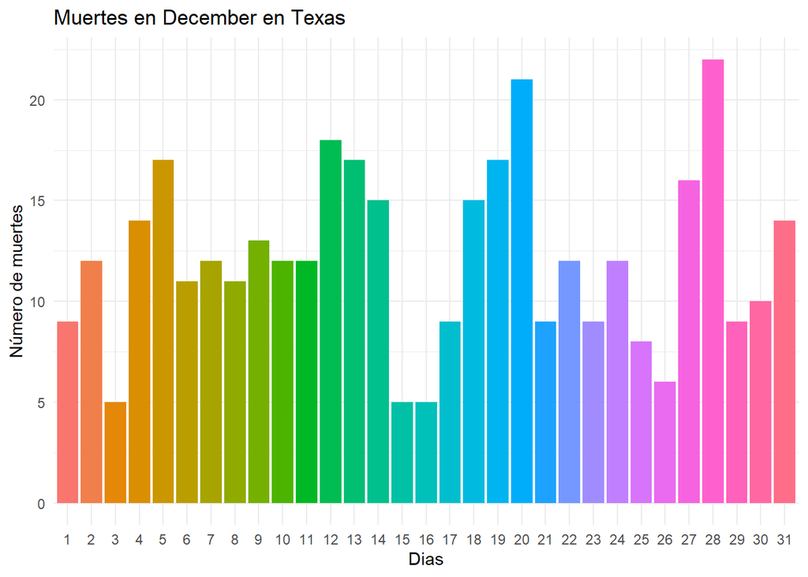

```r
accidentData_estado <- accidentData %>%
  filter(STATENAME == estado_seleccionado & MONTHNAME == mes_seleccionado2)

ggplot(accidentData_estado, aes(x = factor(DAY), y = FATALS, fill = as.factor(DAY))) +
  geom_col() +
  ggtitle(paste("Muertes en", mes_seleccionado2, "en",estado_seleccionado)) +
  labs(x = "Dias", y = "Número de muertes") +
  theme_minimal() +
  theme(legend.position = "none")
```

En caso de Navidades, podemos decir que la operación salida por **Navidades afecta**, ya que el **día 20** es el segundo más accidentado, el primero es el **28**, pudiendo corresponder con la movilización para fin de año.

```r
accidentData_estado <- accidentData %>%
  filter(STATENAME == estado_seleccionado & MONTHNAME == mes_seleccionado1 & DRUNK_DR == 0) %>%
  select(ST_CASE, STATENAME, MONTHNAME, FATALS, DAY, HOUR, DRUNK_DR)

muertes_sobrios <- sum(accidentData_estado$FATALS, na.rm = TRUE)
print(muertes_sobrios)
```

```
## [1] 303
```

En el mes de octubre y en Texas, tenemos **303 muertes que no corresponden a accidentes por alcohol**.

### 2.2.4 Construcción de conjunto de datos final

A partir de estos datos analizados nos vamos a centrar en aquellos accidentes que no han sido causados por el alcohol. Vamos a **vincular estos datos con los registros de los casos de drogas mediante un inner join**, seleccionando así solos los casos que coinciden con la clave primaria ST_CASE.

```r
accidentDataWithDrugs <- inner_join(accidentData_estado, drugsData, by = "ST_CASE")

str(accidentDataWithDrugs)
```

```
## 'data.frame':    796 obs. of  15 variables:
##  $ ST_CASE     : int  482468 482468 482468 482472 482472 482477 482477 482477 482477 482477 ...
##  $ STATENAME.x : chr  "Texas" "Texas" "Texas" "Texas" ...
##  $ MONTHNAME   : chr  "October" "October" "October" "October" ...
##  $ FATALS      : int  1 1 1 1 1 2 2 2 2 2 ...
##  $ DAY         : int  1 1 1 2 2 4 4 4 4 4 ...
##  $ HOUR        : int  16 16 16 10 10 13 13 13 13 13 ...
##  $ DRUNK_DR    : int  0 0 0 0 0 0 0 0 0 0 ...
##  $ STATE       : int  48 48 48 48 48 48 48 48 48 48 ...
##  $ STATENAME.y : chr  "Texas" "Texas" "Texas" "Texas" ...
##  $ VEH_NO      : int  0 1 1 1 2 1 2 3 3 4 ...
##  $ PER_NO      : int  1 1 2 1 1 1 1 1 2 1 ...
##  $ DRUGSPEC    : int  0 0 0 0 0 0 0 0 0 0 ...
##  $ DRUGSPECNAME: chr  "Test Not Given" "Test Not Given" "Test Not Given" "Test Not Given" ...
##  $ DRUGRES     : int  0 0 0 0 0 0 0 0 0 0 ...
##  $ DRUGRESNAME : chr  "Test Not Given" "Test Not Given" "Test Not Given" "Test Not Given" ...
```

#### 2.2.4.1 Codificación

```r
accidentDataWithDrugs$TESTED <- with(accidentDataWithDrugs, ifelse(DRUGRESNAME %in% c("Test Not Given"), 0, 1))
```

#### 2.2.4.2 Normalización

La normalización consiste en ajustar valores numéricos a una escala estándar, y eso es justo lo que necesitamos para tratar el campo DRUGRES. Este dispone de todos los códigos de drogas registrados, pero solo nos interesa saber si se han encontrado o no estupefacientes. Indicaremos un 0 cuando el valor en el registro es 0, es decir, que no se han encontrado drogas o que no se ha realizado ningún test. Si hay otro valor registrado, sabemos que es una codificación del estupefaciente, por lo tanto, valor = 1, indicando que sí se han encontrado drogas.

```r
accidentDataWithDrugs$FINDED <- with(accidentDataWithDrugs, ifelse(DRUGRES %in% c("0", "1"), 0, 1))
```

A partir de los anteriores datos estandarizados podemos realizar los siguientes histogramas:

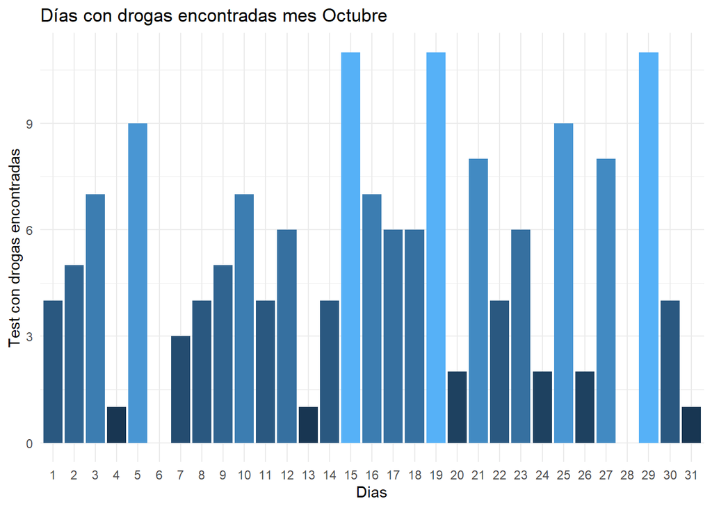

```r
library(ggplot2)
library(dplyr)

objeto <- 1:31

listname <- character(length(objeto))
listfatal <- numeric(length(objeto))
listid <- numeric(length(objeto))

for(i in seq_along(objeto)) {
  elemento <- objeto[i]

  # Recogemos los datos que coinciden con el estado
  matching_rows <- accidentDataWithDrugs[accidentDataWithDrugs$DAY == elemento, ]

  # Recogemos la suma de muertes por estado
  listfatal[i] <- sum(matching_rows$FINDED[matching_rows$FINDED == 1], na.rm = TRUE)
  listid[i] <- i

}

# Creamos un dataframe accidentDataStateFatals a partir de los datos añadidos en la lista
accidentDataWithDrugsAux <- data.frame(DAY = listid, FINDED = listfatal)

#Eliminamos los datos nulos
accidentDataWithDrugsAux <- na.omit(accidentDataWithDrugsAux)


#Recogemos los datos del dataframe creado accidentDataStateFatals
ggplot(accidentDataWithDrugsAux, aes(x = FINDED , y = factor(DAY, levels = 1:31), fill = FINDED)) +
  geom_col() +
  coord_flip() +
  ggtitle("Días con drogas encontradas mes Octubre") +
  labs(x = "Test con drogas encontradas", y = "Dias") +
  theme_minimal() +
  theme(legend.position = "none")
```

Por curiosidad, vamos a hacer un pequeño hincapié en las horas para ver si la cantidad de tests realizados se enlaza con la cantidad de test positivos.

#### 2.2.4.3 Discretización

```r
accidentDataWithDrugs["HOUR_SEG"]<-cut(accidentDataWithDrugs$HOUR, breaks = c(0,6,11,15,17,23), labels = c("Madrugada", "Mañana", "Mediodía", "Anochecer","Noche"))
```

Realizamos los histogramas teniendo en cuenta la transformación de las variables:

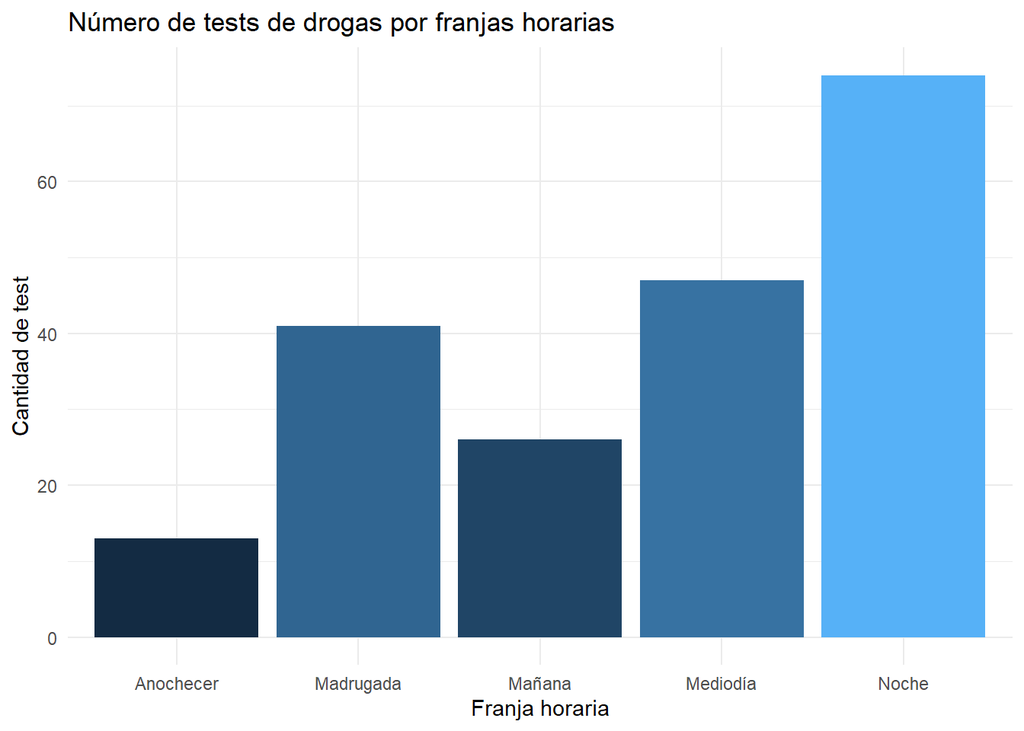

```r
library(ggplot2)
library(dplyr)

objeto <- c("Madrugada", "Mañana", "Mediodía", "Anochecer","Noche")

listname <- character(length(objeto))
listfatal <- numeric(length(objeto))
listid <- numeric(length(objeto))

for(i in seq_along(objeto)) {
  elemento <- objeto[i]
  # Recogemos los datos que coinciden con el estado
  matching_rows <- accidentDataWithDrugs[accidentDataWithDrugs$HOUR_SEG == elemento, ]

  listname[i] <- elemento

  # Recogemos la suma de muertes por estado
  listfatal[i] <- sum(matching_rows$TESTED[matching_rows$TESTED == 1], na.rm = TRUE)
  listid[i] <- i

}

# Creamos un dataframe accidentDataStateFatals a partir de los datos añadidos en la lista
accidentDataWithDrugsAux2 <- data.frame(HOUR_SEG = listname, TESTED = listfatal)

#Eliminamos los datos nulos
accidentDataWithDrugsAux2 <- na.omit(accidentDataWithDrugsAux2)

ggplot(accidentDataWithDrugsAux2, aes(x = TESTED, y = HOUR_SEG, fill = TESTED)) +
  geom_col() +
  coord_flip() +
  ggtitle("Número de tests de drogas por franjas horarias") +
  labs(x = "Cantidad de test", y = "Franja horaria") +
  theme_minimal() +
  theme(legend.position = "none")
```

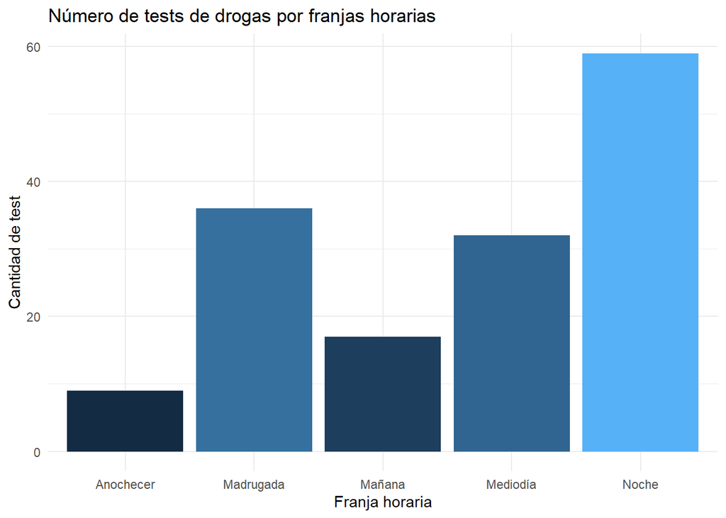

```r
library(ggplot2)
library(dplyr)

objeto <- c("Madrugada", "Mañana", "Mediodía", "Anochecer","Noche")

listname <- character(length(objeto))
listfatal <- numeric(length(objeto))
listid <- numeric(length(objeto))

for(i in seq_along(objeto)) {
  elemento <- objeto[i]
  # Recogemos los datos que coinciden con el estado
  matching_rows <- accidentDataWithDrugs[accidentDataWithDrugs$HOUR_SEG == elemento, ]

  listname[i] <- elemento

  # Recogemos la suma de muertes por estado
  listfatal[i] <- sum(matching_rows$FINDED[matching_rows$FINDED == 1], na.rm = TRUE)
  listid[i] <- i

}

# Creamos un dataframe accidentDataStateFatals a partir de los datos añadidos en la lista
accidentDataWithDrugsAux2 <- data.frame(HOUR_SEG = listname, FINDED = listfatal)

#Eliminamos los datos nulos
accidentDataWithDrugsAux2 <- na.omit(accidentDataWithDrugsAux2)

ggplot(accidentDataWithDrugsAux2, aes(x = FINDED, y = HOUR_SEG, fill = FINDED)) +
  geom_col() +
  coord_flip() +
  ggtitle("Número de tests de drogas por franjas horarias") +
  labs(x = "Cantidad de test", y = "Franja horaria") +
  theme_minimal() +
  theme(legend.position = "none")
```

Con los dos graficos podemos ver que la franja horaria que se han detectado **más test positivos y que se han realizado más tests es por la noche**.

#### 2.2.4.4 Proceso PCA

Como la nomenclatura indica, haremos un análisis de componentes principales para reducir la dimensionalidad de los datos; trabajaremos sobre el proceso PCA.

```r
n = c("ST_CASE","STATE","VEH_NO","PER_NO","DRUGSPEC", "DRUGRES")
drugsDataAux= drugsData %>% select(all_of(n))

#pca.acc <- prcomp(drugsDataAux)
pca.acc <- prcomp(drugsDataAux, scale. = TRUE)  # Normaliza antes de PCA

summary(pca.acc)
```

```
## Importance of components:
##                           PC1    PC2    PC3    PC4    PC5      PC6
## Standard deviation     1.4158 1.1384 1.0075 0.9543 0.8797 0.003805
## Proportion of Variance 0.3341 0.2160 0.1692 0.1518 0.1290 0.000000
## Cumulative Proportion  0.3341 0.5501 0.7192 0.8710 1.0000 1.000000
```

Este método encuentra direcciones de mayor variancia, se puede utilizar sin usar la desviación estándar pero puede distorsionar el análisis de dispersión, especialmente cuando las variables originales tienen escalas muy distintas, como es el caso, y esto llevaría a interpretaciones incorrectas.

Por lo tanto, se ha añadido al comando el valor “scale.” para escalar los datos y utilizar esta desviación estándar.

Los resultados son los siguientes:

```r
if (!require('factoextra')) install.packages('factoextra'); library('factoextra')
#Los valores propios corresponden a la cantidad de variación explicada por cada componente principal (PC).
ev= get_eig(pca.acc)
ev
```

```
##         eigenvalue variance.percent cumulative.variance.percent
## Dim.1 2.004588e+00     3.340980e+01                    33.40980
## Dim.2 1.295870e+00     2.159784e+01                    55.00764
## Dim.3 1.014988e+00     1.691647e+01                    71.92411
## Dim.4 9.106531e-01     1.517755e+01                    87.10166
## Dim.5 7.738858e-01     1.289810e+01                    99.99976
## Dim.6 1.447749e-05     2.412915e-04                   100.00000
```

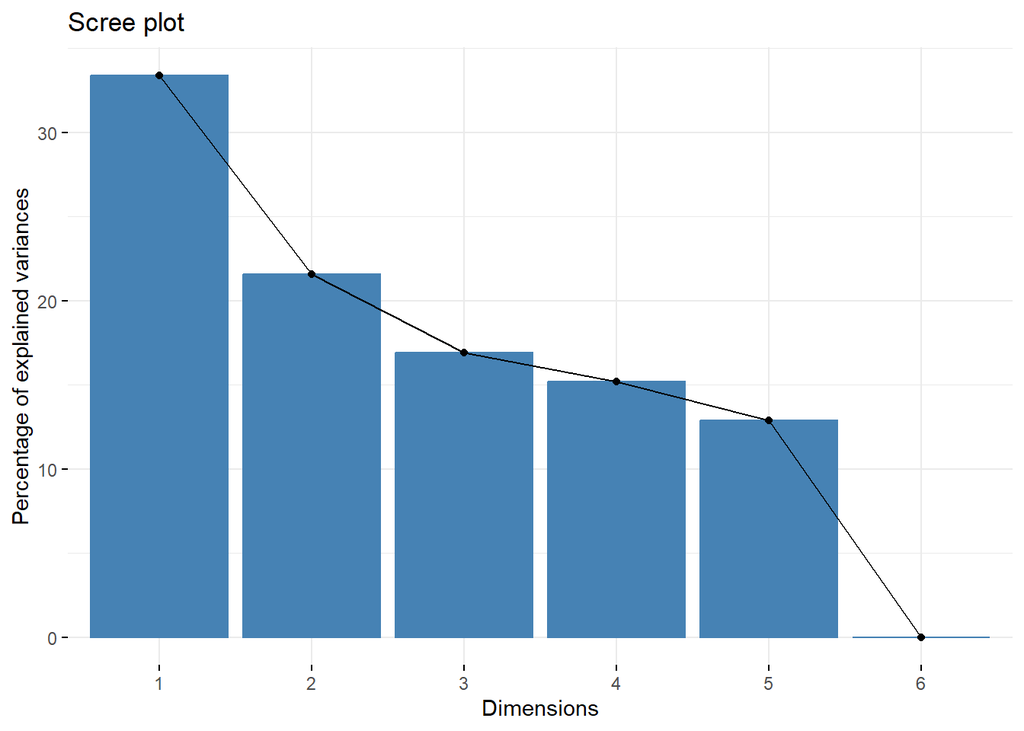

```r
fviz_eig(pca.acc)
```

El gráfico (llamado de codo) muestra que los primeros componentes principales (PC1 y PC2) explican la mayor parte de la variabilidad en los datos, mientras que los siguientes tienen una contribución menor.

Aun así, en este análisis se han utilizado componentes con baja varianza, porque contienen información clave sobre variables específicas, como el uso de drogas. Aunque PCA suele usarse para reducir dimensiones, y según el gráfico se puede reducir a tres, en el caso tratado durante este ejercicio se ha priorizado el análisis de datos para sacar conclusiones. Para mejorar el análisis, se pueden revisar las cargas de cada variable en los PCs o aplicar otras técnicas como clustering o árboles de decisión que también permiten extraer conclusiones más precisas sin perder información relevante.

#### 2.2.4.5 Datos correlación

```r
objeto <- 1:31

listday <- numeric(length(objeto))
listfatal <- numeric(length(objeto))
listdrugs <- numeric(length(objeto))

for(i in seq_along(objeto)) {
  elemento <- objeto[i]

  listday[i] <- elemento

  listfatal[i] <- sum(accidentDataWithDrugs$FATALS[accidentDataWithDrugs$DAY == elemento & accidentDataWithDrugs$FINDED == 1], na.rm = TRUE)

  listdrugs[i] <- sum(accidentDataWithDrugs$FINDED[accidentDataWithDrugs$DAY == elemento & accidentDataWithDrugs$FINDED == 1], na.rm = TRUE)


}

accidentDataFatalsDrugs <- data.frame(DAY = listday, FATALS=listfatal, DRUGS = listdrugs)

accidentDataFatalsDrugs <- na.omit(accidentDataFatalsDrugs)



cor.test(x = accidentDataFatalsDrugs$FATALS, y = accidentDataFatalsDrugs$DRUGS, method = "kendall")
```

```
##
##  Kendall's rank correlation tau
##
## data:  accidentDataFatalsDrugs$FATALS and accidentDataFatalsDrugs$DRUGS
## z = 7.043, p-value = 1.882e-12
## alternative hypothesis: true tau is not equal to 0
## sample estimates:
##       tau
## 0.9510515
```

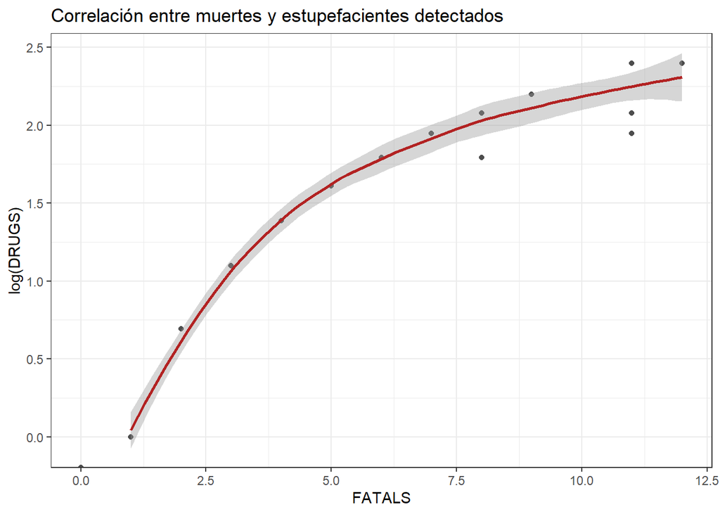

```r
ggplot(data = accidentDataFatalsDrugs, aes(x = FATALS, y = log(DRUGS))) + geom_point(color = "gray30") + geom_smooth(color = "firebrick") + theme_bw() +ggtitle("Correlación entre muertes y estupefacientes detectados")
```

Esta gráfica muestra la correlación entre el número de muertes y la cantidad de estupefacientes detectados, con una transformación logarítmica aplicada a la variable DRUGS.

Podemos ver que, a medida que aumentan las muertes, también aumenta la cantidad de drogas detectadas, pero la relación parece curva en lugar de ser completamente lineal.

Podemos destacar dos componentes en la gráfica: la sombra gris, que indica que un modelo no lineal es más adecuado para describir la relación; la transformación algorítmica sobre la variable DRUGS, que indica que los valores originales posiblemente sean valores un tanto extremos

## 2.3 Implementación de los resultados

Los datos estudiados contemplan accidentes de tráfico con víctimas en las redes de autopistas de EE.UU. a lo largo del 2020, con énfasis en la relación entre el consumo de drogas y la mortalidad en los accidentes. Los registros incluyen un identificador único de accidente y variables principales como número de muertos, conductores implicados, tests de drogas realizados y sus resultados, junto con datos temporales y geográficos.

Los datos se encuentran bien documentados y con un nivel de limpieza aceptable. No se presentan graves problemas de valores nulos o vacíos. Además, la combinación de las bases de datos de accidentes y tests de drogas permite generar nuevas variables relevantes para el estudio.

Podemos afirmar que, a lo largo del 2020, ocurrieron 35,766 accidentes en los que fallecieron 38,824 personas. Se buscó analizar la relación entre el consumo de drogas y la siniestralidad, y las conclusiones fueron significativas. Se encontró una correlación clara entre los tests de drogas realizados y los resultados positivos, ademas que los analisis realizados sugieren una relación entre el consumo de estupefacientes y la presencia de víctimas en los accidentes.

Aún así, para establecer una relación directa entre el consumo de drogas por parte del conductor y la mortalidad en el accidente, se requiere un análisis más profundo, posiblemente con modelos más complejos.

El número más habitual de víctimas mortales por accidente es de una persona. Se ha observado que los conductores ebrios están involucrados en un porcentaje considerable de los accidentes mortales, pero también se detectaron casos de accidentes sin alcohol en los que se encontraron drogas en los test realizados.

A nivel geográfico, Texas, California y Florida fueron los estados con mayor número de accidentes mortales. Al analizar los datos por meses, se observó un incremento en octubre y diciembre, lo que podría estar relacionado con eventos festivos y mayor movilidad. A nivel horario, se determinó que la franja nocturna es la que tiene más tests de drogas y mayor número de positivos, lo que refuerza la hipótesis de que el consumo de sustancias puede estar vinculado a accidentes ocurridos en este horario.

Además, en los datos, se ha aplicado un análisis de componentes principales (PCA) para reducir la dimensionalidad de los datos, los resultados indicaron que los dos primeros componentes principales explican la mayor parte de la variabilidad en los datos, pero no se ha basado el análisis en estas conclusiones.

# 3 Ejercicio 3

A partir del juego de datos utilizado en el ejemplo de la PEC, realiza un análisis exploratorio de datos con el paquete explore() de R y comenta las ventajas e inconvenientes que presenta respecto al análisis realizado en el ejercicio 2.

Puedes utilizar la documentación publicada del paquete explore() en https://github.com/rolkra/explore

```r
if(!require('explore')) install.packages('explore'); library('explore')

explore(accidentData)
```

## 3.1 Análisis Exploratorio del Conjunto de Datos

El conjunto de datos analizado con explore() de R contiene 35,766 observaciones y 81 variables, abarca toda la información sobre accidentes y sus factores relacionados presentados en el dataset principal (no se ha realizado un analisis del dataset de drogas). En este analisis automatico se verifica la calidad de los datos y la falta de datos en las variables.

### 3.1.1 Variables generales

La variable **STATE** tiene 51 valores únicos, lo que indica que los datos provienen de todos los estados de EE. UU. Además, **COUNTYNAME** y **CITYNAME** muestran variedad de valores únicos, lo que indica que los accidentes están distribuidos en distintas zonas.

La variable **YEAR** no tiene de variabilidad, ya que todos los registros pertenecen al año 2020. En cambio, las variables **DAY, MONTH, HOUR** ayudan a analizar patrones temporales.

La variable **FATALS** tiene un valor máximo de 8, lo que sugiere que el accidente más letal en la base de datos registró esa cantidad de víctimas.

**DRUNK_DR** muestra una media de 0.27, lo que indica que una pequeña proporción de los accidentes involucran conductores ebrios, aunque no es un factor en el que se centra el análisis.

### 3.1.2 Datos Inusuales

La variable **HOUR** tiene valores de 99, que obviamente son erróneos, ya que la hora máxima válida debería ser 23. Esto podría representar que los datos codificados son incorrectos o hay registros erróneos.

El análisis exploratorio general muestra al detalle el conjunto de datos, mostrando una gráfica para cada variable analizada. Podemos decir, grosso modo, que los datos están limpios pero con ciertas anomalías en variables de tiempo y geolocalización. Existen datos interesantes como la distribución horaria y en la severidad de los accidentes, además de la posible influencia del alcohol y posteriormente del consumo de drogas.

## 3.2 Ventajas y desventajas de explore()

El paquete explore() presenta estadísticas básicas y un desglose del tipo de variables, la cantidad de valores únicos, mínimos, máximos y medias, además de verificar valores faltantes.

El uso de esta librería ofrece varias ventajas, ya que automatiza los resúmenes estadísticos y la detección de valores atípicos, y proporciona una visión general rápida sin la necesidad de escribir código previo. Además, permite manejar grandes volúmenes de datos, ya que facilita la identificación de patrones antes de un análisis más profundo.

Sin embargo, como desventaja, el usuario tiene menos control sobre la personalización del análisis y la selección de las métricas. Si se trabaja de manera manual, se pueden diseñar visualizaciones y métricas más adaptadas a los objetivos del estudio, mientras que explore() se generan resultados generales que pueden no ser suficientes para el caso.

En conclusión, es útil para un primer vistazo general de las métricas, pero no reemplaza al análisis manual en profundidad.